# Conjoint Analysis - Tory Horse Case

Winters

## Case Background

A Tory horse company is considering to use conjoint data to understand the segmentation of customers, also product line pricing, and also do market stimulation for completition. It collected the rating choice data from 200 parents who have a 2 or 3-4 year-old child.

Key information are shown below: A Priori Segmentation: Gender(Female/Male) and Age(2/3 to 4)

Product Attributes & Level: Price(119.99/139.99), Height(18 inch / 26 inch), Motion(Rocking/Bouncing), Style(Glamorous/Racing)

Product Profilo: P13: $139.99 + 18 inch + Glamorous + Rocking (Our offering) P5: $139.99 + 18 inch + Racing + Rocking (Our offering) P7: $139.99 + 26 inch + Racing + Rocking (Competitor)

Market Size: 4000 Units Fixed Cost Per Product Line Per Year: 20,000 Product Switching Cost: One Third of the product line cost Whole Sales Price: 111.99 for 139.99, 95.99 for 119.99 Product Variable Costs

Product | VC 18" Rocking | 33 26" Rocking | 41 18" Bouncing | 21 26" Bouncing | 29 Styling does not change the variable costs.

## Analytical Purpose

A. Conduct Benefit Segementation via Cluster Analysis B. Test a priori segmentation and learn the perference of a priori segmentation C. Simulate market shares for different product-line scenarios and competitive response

## Analytical Process

1. Use Regression to estimate the conjoint model at the individual level and predict for missing profile
2. Conduct Benefit Segmentation via Cluster Analysis of Conjoint Part-Utilities.
3. Conduct a priori segmentation and finding insight from the a priori segmentation
4. Simulate market shares for different product-line scenarios.

# Data Load and Data Quality Check

```r
filename <- "GBA424 - Toy Horse Case Data"
datainput <- load(paste0(filename,".RData"))
str(conjointData)
```

```
## 'data.frame':    3200 obs. of  7 variables:
##  $ ID     : int  1 1 1 1 1 1 1 1 1 1 ...
##  $ profile: int  1 2 3 4 5 6 7 8 9 10 ...
##  $ ratings: num  44.6 46 NA 75.4 43.2 ...
##  $ price  : num  0 1 0 1 0 1 0 1 0 1 ...
##  $ size   : num  0 0 1 1 0 0 1 1 0 0 ...
##  $ motion : num  0 0 0 0 1 1 1 1 0 0 ...
##  $ style  : num  0 0 0 0 0 0 0 0 1 1 ...
```

```r
str(profilesData)
```

```
## 'data.frame':    16 obs. of  9 variables:
##  $ profile    : int  1 2 3 4 5 6 7 8 9 10 ...
##  $ price      : num  0 1 0 1 0 1 0 1 0 1 ...
##  $ size       : num  0 0 1 1 0 0 1 1 0 0 ...
##  $ motion     : num  0 0 0 0 1 1 1 1 0 0 ...
##  $ style      : num  0 0 0 0 0 0 0 0 1 1 ...
##  $ priceLabel : num  140 120 140 120 140 ...
##  $ sizeLabel  : Factor w/ 2 levels "18 inches","26 inches": 1 1 2 2 1 1 2 2 1 1 ...
##  $ motionLabel: Factor w/ 2 levels "Bouncing","Rocking": 1 1 1 1 2 2 2 2 1 1 ...
##  $ styleLabel : Factor w/ 2 levels "Glamour","Racing": 2 2 2 2 2 2 2 2 1 1 ...
```

```r
str(respondentData)
```

```
## 'data.frame':    200 obs. of  3 variables:
##  $ ID    : int  1 2 3 4 5 6 7 8 9 10 ...
##  $ age   : int  1 0 1 0 0 1 0 0 1 0 ...
##  $ gender: int  1 1 1 1 1 0 1 1 1 0 ...
```

```r
apply(conjointData,2, function(x) any(is.na(x))) # NA in ratings
```

```
##      ID profile ratings   price    size  motion   style
##   FALSE   FALSE    TRUE   FALSE   FALSE   FALSE   FALSE
```

```r
apply(respondentData,2, function(x) any(is.na(x))) # No NA detected
```

```
##     ID    age gender
##  FALSE  FALSE  FALSE
```

```r
apply(profilesData,2, function(x) any(is.na(x))) # No NA detected
```

```
##     profile       price        size      motion       style  priceLabel
##       FALSE       FALSE       FALSE       FALSE       FALSE       FALSE
##   sizeLabel motionLabel  styleLabel
##       FALSE       FALSE       FALSE
```

```r
head(conjointData[is.na(conjointData$ratings),"profile"], 10)
```

```
##  [1]  3  6 10 16  3  6 10 16  3  6
```

From the analysis above, we find the for profile 3,6,10,16, they are missing. This is because they are not included in the conjoint testing so we need to predict those rating according to each individual partworths.

# Step 1: Use Regression to estimate the conjoint model at the individual level and predict for missing profile

```r
individual_partworths <- data.frame( ID = 1:200, 'Intercept' = rep(NA, 200), 'priceLow' = rep(NA, 200), 'sizeLarge' = rep(NA,200), 'motionRocking'= rep(NA,200), 'styleGlamourous' = rep(NA,200))

for (i in 1:200) {
  model <- lm(ratings~price+size+motion+style, data = conjointData[conjointData$ID == i,])
  for (k in 1:16) {
    if (is.na(conjointData[conjointData$ID == i & conjointData$profile == k,3])) {
      conjointData[conjointData$ID == i & conjointData$profile == k,3] <-
        predict(model,conjointData[conjointData$ID == i & conjointData$profile == k,3:7])
    } else NULL
  }
  for (j in 2:6) {
    individual_partworths[i,j] <- coef(model)[j-1]
  }
}

head(individual_partworths,5)
```

```
##   ID Intercept  priceLow  sizeLarge motionRocking styleGlamourous
## 1  1  42.16541  8.600463  21.334432      6.289641       11.815359
## 2  2  40.17178 13.059091 -10.750520     15.780864       -3.018138
## 3  3  51.99862  7.226711  14.051471      6.034665        7.448577
## 4  4  49.05301  9.573213  19.270947      4.736483        5.486421
## 5  5  27.91527 24.186384   5.222476     -6.705663       -6.788886
```

```r
head(conjointData,6)
```

```
##   ID profile  ratings price size motion style
## 1  1       1 44.63739     0    0      0     0
## 2  1       2 45.97442     1    0      0     0
## 3  1       3 63.49984     0    1      0     0
## 4  1       4 75.38910     1    1      0     0
## 5  1       5 43.21365     0    0      1     0
## 6  1       6 57.05551     1    0      1     0
```

# Step 2: Conduct Benefit Segmentation via Cluster Analysis of Conjoint Part-Utilities.

```r
library(mclust)
```

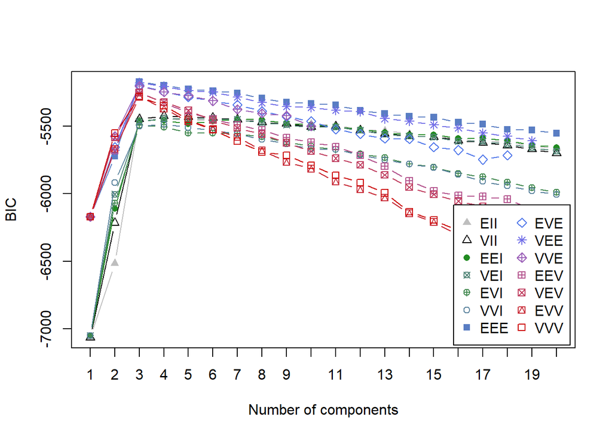

```r
declass_partworths <- individual_partworths[,-1]
m_clust <- Mclust(as.matrix(declass_partworths), G = 1:20)
plot(m_clust, "BIC")
```

From the chart above, we can infer that the number of cluster should be somewhere around 3. But we need use more method to confirm this finding.

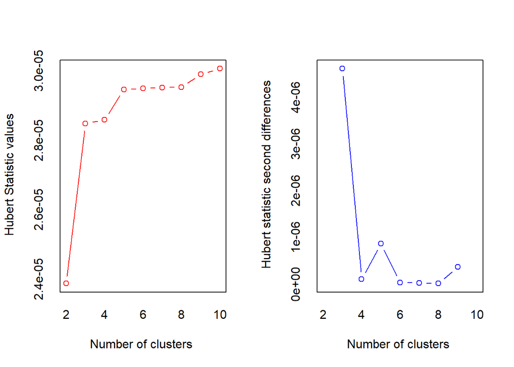

```
## *** : The Hubert index is a graphical method of determining the number of clusters.
##                 In the plot of Hubert index, we seek a significant knee that corresponds to a
##                 significant increase of the value of the measure i.e the significant peak in Hubert
##                 index second differences plot.
##
```

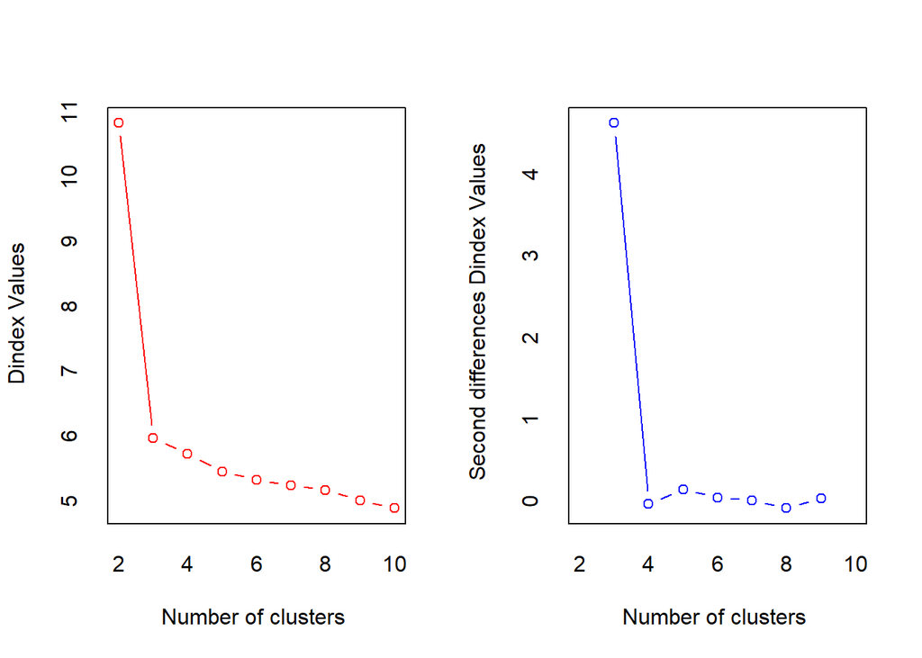

```
## *** : The D index is a graphical method of determining the number of clusters.
##                 In the plot of D index, we seek a significant knee (the significant peak in Dindex
##                 second differences plot) that corresponds to a significant increase of the value of
##                 the measure.
##
## * Among all indices:
## * 1 proposed 2 as the best number of clusters
## * 23 proposed 3 as the best number of clusters
## * 2 proposed 4 as the best number of clusters
## * 1 proposed 10 as the best number of clusters
##
##                    ***** Conclusion *****
##
## * According to the majority rule, the best number of clusters is  3
##
##
```

```r
library(NbClust)
set.seed(1234)
nb_clust <- NbClust(declass_partworths,distance = "euclidean",min.nc=2, max.nc=10, method = "kmeans",index = "alllong", alphaBeale = 0.1)
```

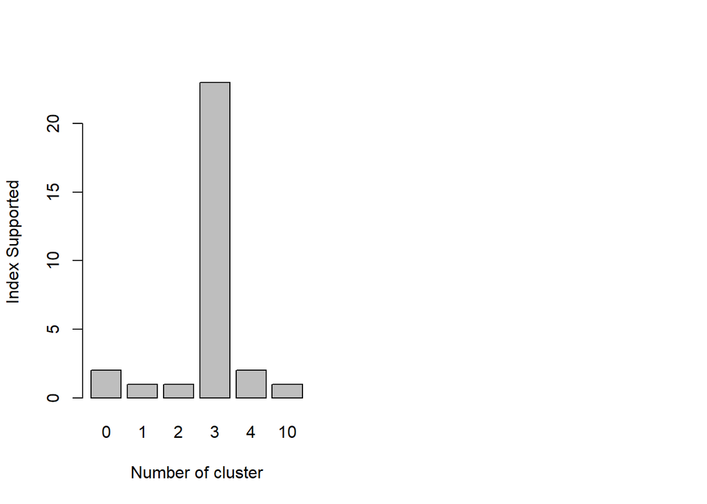

```r
barplot(table(nb_clust$Best.nc[1,]),xlab = "Number of cluster",ylab = "Index Supported")
```

According to the majority rule, the best number of clusters is 3.

**WSS & Silhouette** Create a clustTest functon and apply within sum of squared errors as well average silhouette width to do cluster analysis.

```r
library(cluster)
library(fpc)
library(factoextra)
```

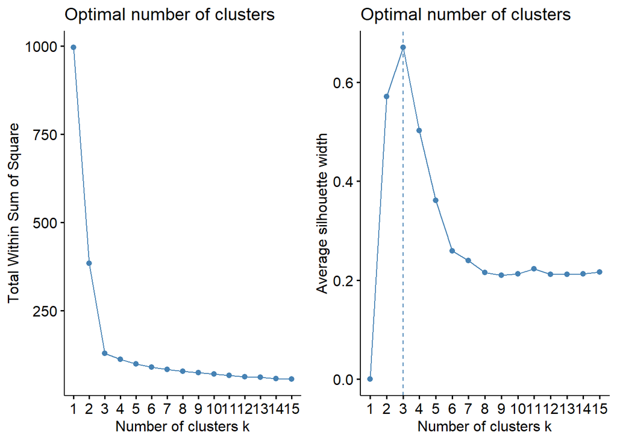

```
## $wss
##  [1] 995.00000 383.84977 128.60229 111.91819  98.14994  88.99271  82.89681
##  [8]  77.15171  73.46641  68.69521  64.82040  61.51011  59.94983  56.69644
## [15]  55.22111
##
## $pm1
## [1] 3
##
## $gpw
```

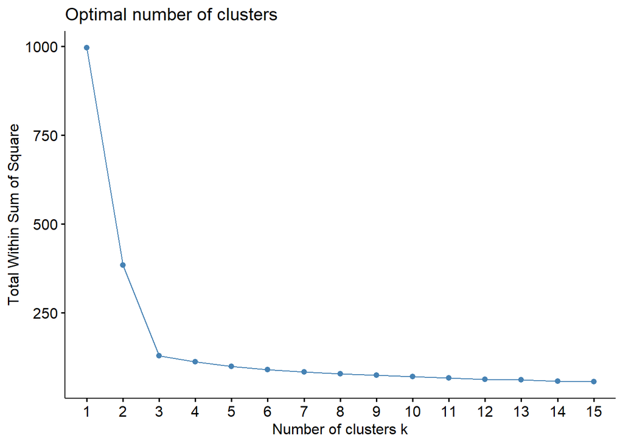

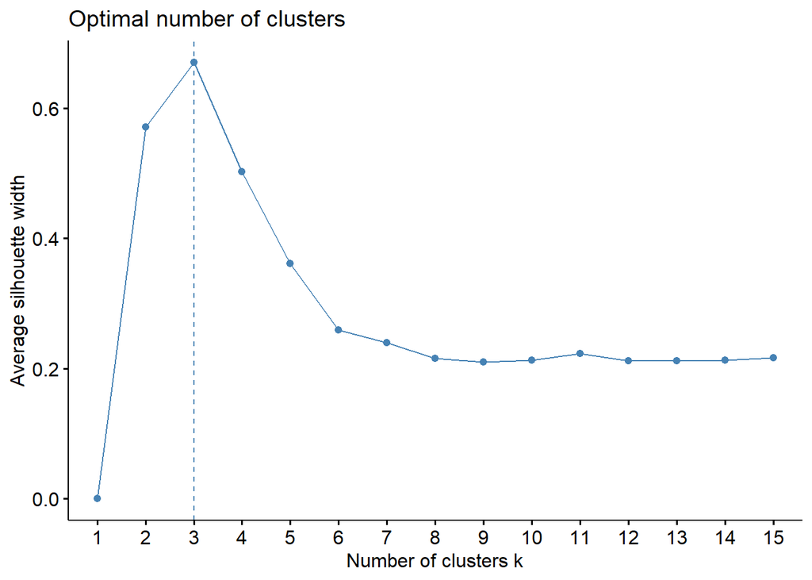

```r
library(gridExtra)

clustTest = function(toClust,print=TRUE,scale=TRUE,maxClusts=15,seed=12345,nstart=20,iter.max=100){
  if(scale){ toClust = scale(toClust);}
  set.seed(seed)
  wss <- (nrow(toClust)-1)*sum(apply(toClust,2,var))
  for (i in 2:maxClusts) wss[i] <- sum(kmeans(toClust,centers=i,nstart=nstart,iter.max=iter.max)$withinss)
  gpw = fviz_nbclust(toClust,kmeans,method="wss",iter.max=iter.max,nstart=nstart,k.max=maxClusts)
  pm1 = pamk(toClust,scaling=TRUE)
  gps = fviz_nbclust(toClust,kmeans,method="silhouette",iter.max=iter.max,nstart=nstart,k.max=maxClusts)
  if(print){
    grid.arrange(gpw,gps, nrow = 1)
  }
  list(wss=wss,pm1=pm1$nc,gpw=gpw,gps=gps)
}
clustTest(declass_partworths)
```

The result is also confirmed with two method above. So we are quite confident the 3 clusters perhaps is a good way to do the segmentation.

# Visualizing what is in the cluster?

Using kmeans we plot three graph to describe the details within those clusters： pie chart with participant percentages ellipse plot that indicates cluster definitions against principle components barplot of the cluster means

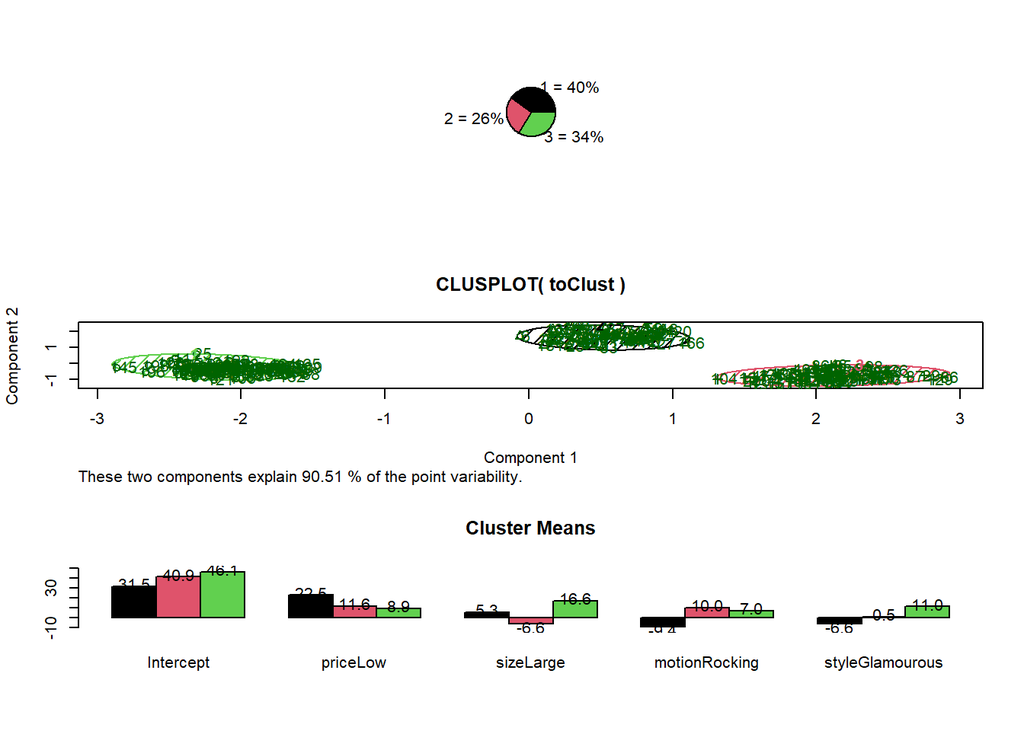

```r
set.seed(12345)
km <- kmeans(declass_partworths,3,iter.max = 100, nstart = 20)
plotClust = function(km,toClust,discPlot=FALSE){
  nc = length(km$size)
  if(discPlot){par(mfrow=c(2,2))}
  else {par(mfrow=c(3,1))}
  percsize = paste(1:nc," = ",format(km$size/sum(km$size)*100,digits=2),"%",sep="")
  pie(km$size,labels=percsize,col=1:nc)

  clusplot(toClust, km$cluster, color=TRUE, shade=TRUE,
           labels=2, lines=0,col.clus=1:nc); #plot clusters against principal components

  if(discPlot){
    plotcluster(toClust, km$cluster,col=km$cluster); #plot against discriminant functions ()
  }
  rng = range(km$centers)
  dist = rng[2]-rng[1]
  locs = km$centers+.05*dist*ifelse(km$centers>0,1,-1)
  bm = barplot(km$centers,beside=TRUE,col=1:nc,main="Cluster Means",ylim=rng+dist*c(-.1,.1))
  text(bm,locs,formatC(km$centers,format="f",digits=1))
}
plotClust(km, declass_partworths)
```

## Step 3: Conduct a priori segmentation and finding insight from the a priori segmentation

A priori segmentation is focus on age and gender. Therefore, we include age, and gender as the interaction effect in the regression.

```r
a_priori <- merge(conjointData,respondentData, on = "ID", all = T)
a_priori <- a_priori[,c(-1,-2)]
summary(lm(ratings~.,data = a_priori))
```

```
##
## Call:
## lm(formula = ratings ~ ., data = a_priori)
##
## Residuals:
##     Min      1Q  Median      3Q     Max
## -41.262 -11.270  -0.691  10.777  41.943
##
## Coefficients:
##             Estimate Std. Error t value Pr(>|t|)
## (Intercept)  34.5194     0.7092  48.675  < 2e-16 ***
## price        15.0490     0.5383  27.957  < 2e-16 ***
## size          5.9594     0.5383  11.071  < 2e-16 ***
## motion        1.2200     0.5383   2.266  0.02349 *
## style         1.1434     0.5383   2.124  0.03373 *
## age          -1.4009     0.5429  -2.580  0.00991 **
## gender        9.4050     0.5446  17.269  < 2e-16 ***
## ---
## Signif. codes:  0 '***' 0.001 '**' 0.01 '*' 0.05 '.' 0.1 ' ' 1
##
## Residual standard error: 15.23 on 3193 degrees of freedom
## Multiple R-squared:  0.2752, Adjusted R-squared:  0.2738
## F-statistic:   202 on 6 and 3193 DF,  p-value: < 2.2e-16
```

```r
summary(lm(ratings~(price+size+motion+style)*age, data = a_priori))
```

```
##
## Call:
## lm(formula = ratings ~ (price + size + motion + style) * age,
##     data = a_priori)
##
## Residuals:
##     Min      1Q  Median      3Q     Max
## -43.528 -11.829  -2.007  11.634  44.386
##
## Coefficients:
##             Estimate Std. Error t value Pr(>|t|)
## (Intercept)  39.5462     0.8917  44.350  < 2e-16 ***
## price        14.4133     0.7975  18.072  < 2e-16 ***
## size          3.8532     0.7975   4.831 1.42e-06 ***
## motion        2.7950     0.7975   3.504 0.000464 ***
## style         1.1867     0.7975   1.488 0.136877
## age          -1.2982     1.2548  -1.035 0.300928
## price:age     1.2588     1.1223   1.122 0.262095
## size:age      4.1708     1.1223   3.716 0.000206 ***
## motion:age   -3.1188     1.1223  -2.779 0.005486 **
## style:age    -0.0857     1.1223  -0.076 0.939140
## ---
## Signif. codes:  0 '***' 0.001 '**' 0.01 '*' 0.05 '.' 0.1 ' ' 1
##
## Residual standard error: 15.87 on 3190 degrees of freedom
## Multiple R-squared:  0.2131, Adjusted R-squared:  0.2109
## F-statistic: 95.98 on 9 and 3190 DF,  p-value: < 2.2e-16
```

```r
summary(lm(ratings~(price+size+motion+style)*gender, data = a_priori))
```

```
##
## Call:
## lm(formula = ratings ~ (price + size + motion + style) * gender,
##     data = a_priori)
##
## Residuals:
##    Min     1Q Median     3Q    Max
## -45.67 -10.97  -0.52  10.74  47.02
##
## Coefficients:
##               Estimate Std. Error t value Pr(>|t|)
## (Intercept)    36.5668     0.8801  41.547  < 2e-16 ***
## price          16.8573     0.7872  21.414  < 2e-16 ***
## size            3.8509     0.7872   4.892 1.05e-06 ***
## motion         -0.7601     0.7872  -0.966 0.334327
## style          -1.8895     0.7872  -2.400 0.016440 *
## gender          4.3032     1.1977   3.593 0.000332 ***
## price:gender   -3.3488     1.0713  -3.126 0.001788 **
## size:gender     3.9046     1.0713   3.645 0.000272 ***
## motion:gender   3.6669     1.0713   3.423 0.000627 ***
## style:gender    5.6165     1.0713   5.243 1.68e-07 ***
## ---
## Signif. codes:  0 '***' 0.001 '**' 0.01 '*' 0.05 '.' 0.1 ' ' 1
##
## Residual standard error: 15.1 on 3190 degrees of freedom
## Multiple R-squared:  0.2876, Adjusted R-squared:  0.2856
## F-statistic: 143.1 on 9 and 3190 DF,  p-value: < 2.2e-16
```

```r
maleData <- a_priori[a_priori$gender=="0",]
femaleData <- a_priori[a_priori$gender=="1",]
summary(lm(ratings~price+size+motion+style,data=maleData)) #style significant
```

```
##
## Call:
## lm(formula = ratings ~ price + size + motion + style, data = maleData)
##
## Residuals:
##     Min      1Q  Median      3Q     Max
## -33.917  -9.740  -2.504   7.017  47.017
##
## Coefficients:
##             Estimate Std. Error t value Pr(>|t|)
## (Intercept)  36.5668     0.7991  45.760  < 2e-16 ***
## price        16.8573     0.7147  23.585  < 2e-16 ***
## size          3.8509     0.7147   5.388 8.29e-08 ***
## motion       -0.7601     0.7147  -1.063  0.28773
## style        -1.8895     0.7147  -2.644  0.00829 **
## ---
## Signif. codes:  0 '***' 0.001 '**' 0.01 '*' 0.05 '.' 0.1 ' ' 1
##
## Residual standard error: 13.71 on 1467 degrees of freedom
## Multiple R-squared:  0.288,  Adjusted R-squared:  0.2861
## F-statistic: 148.4 on 4 and 1467 DF,  p-value: < 2.2e-16
```

```r
summary(lm(ratings~price+size+motion+style,data=femaleData))
```

```
##
## Call:
## lm(formula = ratings ~ price + size + motion + style, data = femaleData)
##
## Residuals:
##     Min      1Q  Median      3Q     Max
## -45.675 -12.784   2.696  12.527  36.175
##
## Coefficients:
##             Estimate Std. Error t value Pr(>|t|)
## (Intercept)   40.870      0.871  46.926  < 2e-16 ***
## price         13.509      0.779  17.341  < 2e-16 ***
## size           7.755      0.779   9.956  < 2e-16 ***
## motion         2.907      0.779   3.731 0.000197 ***
## style          3.727      0.779   4.784 1.86e-06 ***
## ---
## Signif. codes:  0 '***' 0.001 '**' 0.01 '*' 0.05 '.' 0.1 ' ' 1
##
## Residual standard error: 16.19 on 1723 degrees of freedom
## Multiple R-squared:  0.2022, Adjusted R-squared:  0.2003
## F-statistic: 109.2 on 4 and 1723 DF,  p-value: < 2.2e-16
```

Children from both gender perfer low price, bigger size. Boys seem to prefer racing over glamorous. No obvious prefernce among motion type. Girls seem to prefer rocking over bouncing and glamorous over racing.

```r
twoData <- a_priori[a_priori$age=="0",]
threefourData <- a_priori[a_priori$age=="1",]
summary(lm(ratings~price+size+motion+style,data=twoData)) #motion significant
```

```
##
## Call:
## lm(formula = ratings ~ price + size + motion + style, data = twoData)
##
## Residuals:
##     Min      1Q  Median      3Q     Max
## -43.528 -10.547  -1.265   9.285  43.040
##
## Coefficients:
##             Estimate Std. Error t value Pr(>|t|)
## (Intercept)  39.5462     0.8348  47.375  < 2e-16 ***
## price        14.4133     0.7466  19.305  < 2e-16 ***
## size          3.8532     0.7466   5.161 2.77e-07 ***
## motion        2.7950     0.7466   3.744 0.000188 ***
## style         1.1867     0.7466   1.589 0.112174
## ---
## Signif. codes:  0 '***' 0.001 '**' 0.01 '*' 0.05 '.' 0.1 ' ' 1
##
## Residual standard error: 14.86 on 1579 degrees of freedom
## Multiple R-squared:  0.2085, Adjusted R-squared:  0.2065
## F-statistic:   104 on 4 and 1579 DF,  p-value: < 2.2e-16
```

```r
summary(lm(ratings~price+size+motion+style,data=threefourData))
```

```
##
## Call:
## lm(formula = ratings ~ price + size + motion + style, data = threefourData)
##
## Residuals:
##     Min      1Q  Median      3Q     Max
## -37.465 -13.222  -3.291  14.156  44.386
##
## Coefficients:
##             Estimate Std. Error t value Pr(>|t|)
## (Intercept)  38.2480     0.9348  40.917   <2e-16 ***
## price        15.6721     0.8361  18.745   <2e-16 ***
## size          8.0239     0.8361   9.597   <2e-16 ***
## motion       -0.3238     0.8361  -0.387    0.699
## style         1.1010     0.8361   1.317    0.188
## ---
## Signif. codes:  0 '***' 0.001 '**' 0.01 '*' 0.05 '.' 0.1 ' ' 1
##
## Residual standard error: 16.81 on 1611 degrees of freedom
## Multiple R-squared:  0.2166, Adjusted R-squared:  0.2146
## F-statistic: 111.3 on 4 and 1611 DF,  p-value: < 2.2e-16
```

Interesting, three to four year-old kid seems have no preference in motion and style. While two year-old seems to prefer rocking.

## Step 4: Simulate market shares for different product-line scenarios and competitive response

Reshape the data into a wide format. Build functions to calculate the shares for different options. Solving ties problems, using another matrix to map the largest rating for a customer and then calculate the shares.

```r
rating_profile <- conjointData[,c(1,2,3)]
library("reshape")
rating_profile <- cast(rating_profile, formula = ID ~ profile)
colnames(rating_profile) <- c('id',paste("Profile", 1:16, sep = '_'))

simFCDecisions = function(scen,data,ascend=FALSE){
  test = data[,scen]
  Matrix = matrix(0,200,length(test))
  colnames(Matrix) = colnames(test)
  test$max = 0
  if(ascend){
    for (y in 1:200){
      test$max[y] = min(test[y,])
    }
  } else {
    for (y in 1:200){
      test$max[y] = max(test[y,])
    }
  }
  for (r in 1:200){
    for (c in 1:(length(test)-1)){
      if(test[r,c]==test[r,"max"]){
        Matrix[r,c] = 1
      }
    }
  }
  Matrix = as.data.frame(Matrix)
  Matrix
}

calcUnitShares = function(decisions){
  colSums(decisions)/sum(decisions)
}

simFCShares=function(scen,data,ascend=FALSE){
  decs = simFCDecisions(scen,data,ascend)
  calcUnitShares(decs)
}
```

**Finding the existing market scen** We have the profile 13,5,7 in the market and 13,5 are ours.

```r
c1 <- simFCShares(c(5,13,7),rating_profile[,2:17])
c1
```

```
##  Profile_5 Profile_13  Profile_7
##       0.22       0.21       0.57
```

Now we have a total share of 43 percent.

What if the competitors change their price lowering their price from 139.99 to 119.99?

```r
c2 <- simFCShares(c(5,13,8), rating_profile[,2:17])
c2
```

```
##  Profile_5 Profile_13  Profile_8
##      0.030      0.045      0.925
```

From the market simulation above we find we might only have 7 per cent of share in the market

**Plan A and Plan B**

```r
#Plan A
simFCShares(c(3,7,15),rating_profile[,2:17])
```

```
##  Profile_3  Profile_7 Profile_15
##      0.385      0.170      0.445
```

```r
#revenue = (111.99-29)*4000*0.3823529 = 126925.9
#revenue = (111.99-41)*4000*0.4411765  = 125276.5
#cost = 20000*2+20000/3*2 = 53333.33
#profit = 126925.9+125276.5-53333.33 = 198869.1
simFCShares(c(4,8,16),rating_profile[,2:17])
```

```
##  Profile_4  Profile_8 Profile_16
##      0.355      0.180      0.465
```

```r
#revenue = (95.99-29)*4000*0.3474178 = 93094.07
#revenue = (95.99-41)*4000*0.4507042 = 99136.9
#cost = 20000*2 = 40000
#profit = 93094.07+99136.9-40000 = 152231
#totalprofit = 198869.1+152231*4 = 807793.1

#Plan B
simFCShares(c(5,7,13),rating_profile[,2:17]) #current
```

```
##  Profile_5  Profile_7 Profile_13
##       0.22       0.57       0.21
```

```r
simFCShares(c(7,11),rating_profile[,2:17]) #first year
```

```
##  Profile_7 Profile_11
##      0.425      0.575
```

```r
#revenue = (111.99-29)*4000*0.563981 = 187219.1
#cost = 20000+20000/3 = 26666.67
#profit = 187219.1-26666.67 = 160552.4
simFCShares(c(2,7),rating_profile[,2:17]) #second year
```

```
## Profile_2 Profile_7
##      0.66      0.34
```

```r
#revenue = (95.99-21)*4000*0.6568627 = 197032.5
#cost = 20000+20000/3 = 26666.67
#profit = 197032.5-26666.67 = 170365.8
simFCShares(c(2,7,15),rating_profile[,2:17]) #third year
```

```
##  Profile_2  Profile_7 Profile_15
##      0.625      0.040      0.335
```

```r
#revenue = (95.99-21)*4000*0.62376238 = 187103.8
#revenue = (111.99-41)*4000*0.33168317 = 94184.75
#cost = 20000*2+20000/3 = 46666.67
#profit = 187103.8+94184.75-46666.67 = 234621.9
simFCShares(c(2,8,16),rating_profile[,2:17])
```

```
##  Profile_2  Profile_8 Profile_16
##      0.325      0.255      0.420
```

```r
#revenue = (95.99-21)*4000*0.3287037 = 98597.96
#revenue = (95.99-41)*4000*0.4074074 = 89613.33
#cost = 20000*2 = 40000
#profit = 98597.96+89613.33-40000 = 148211.3
#totalprofit = 160552.4+170365.8+234621.9+148211.3*2 = 861962.7

#Plan B (sensitivity analysis)
simFCShares(c(5,7,13),rating_profile[,2:17]) #current
```

```
##  Profile_5  Profile_7 Profile_13
##       0.22       0.57       0.21
```

```r
simFCShares(c(7,11),rating_profile[,2:17]) #first year
```

```
##  Profile_7 Profile_11
##      0.425      0.575
```

```r
#revenue = (111.99-29)*4000*0.563981 = 187219.1
#cost = 20000+20000/3 = 26666.67
#profit = 187219.1-26666.67 = 160552.4
simFCShares(c(2,7),rating_profile[,2:17]) #second year
```

```
## Profile_2 Profile_7
##      0.66      0.34
```

```r
#revenue = (95.99-21)*4000*0.6568627 = 197032.5
#cost = 20000+20000/3 = 26666.67
#profit = 197032.5-26666.67 = 170365.8
simFCShares(c(2,8,15),rating_profile[,2:17]) #third year
```

```
##  Profile_2  Profile_8 Profile_15
##      0.335      0.445      0.220
```

```r
#revenue = (95.99-21)*4000*0.3461538 = 103832.3
#revenue = (111.99-41)*4000*0.2163462 = 61433.67
#cost = 20000*2+20000/3 = 46666.67
#profit = 103832.3+61433.67-46666.67 = 118599.3
simFCShares(c(2,8,16),rating_profile[,2:17]) #forth year
```

```
##  Profile_2  Profile_8 Profile_16
##      0.325      0.255      0.420
```

```r
#revenue = (95.99-21)*4000*0.3287037 = 98597.96
#revenue = (95.99-41)*4000*0.4074074  = 89613.33
#cost = 20000*2 = 40000
#profit = 98597.96+89613.33-40000 = 148211.3
#totalprofit = 160552.4+170365.8+118599.3+148211.3*2 = 745940.1
#total = 861962.7*0.6+745940.1*0.4 = 815553.7
```